# Tarea 5. Diferenciación e integración numérica.

Author

Alexander Fuentes Gómez

Importamos packages y funciones necesarias:

```python
import matplotlib.pyplot as plt
import numpy as np
import math

import plotly.graph_objects as go
from scipy.differentiate import derivative
import numdifftools as nd
from scipy import integrate
import pandas as pd

# Paquetes auxiliares para valores exactos
import sympy as sp
from scipy import special, stats
```

# Ejercicio 1.

Para cada una de las siguientes funciones:

- Realiza la respectiva gráfica en el intervalo dado.
- Compara las gráficas de las derivadas aproximadas de la función `derivative` de `Scipy`, con dos tamaños de paso utilizando la función `nd.Derivative` (con `order =2` y `order = 4`, con las opciones de `method`: `forward`, `backward`, `central`) y la derivada *exacta* en tal intervalo.
- Compara las gráficas de las segundas derivadas aproximadas con dos tamaños de paso utilizando la función `nd.Derivative` y la segunda derivada *exacta* en tal intervalo.
- Realiza las gráficas de los errores absolutos en cada caso.

Definimos una función auxiliar que realiza todas las comparaciones solicitadas. Para cada función se usan **dos tamaños de paso** ($h_1$ y $h_2$), los tres **métodos** (`forward`, `central`, `backward`) y los dos **órdenes** de aproximación (`order = 2` y `order = 4`).

```python
def analiza_derivadas(f, fp, fpp, a, b, etiqueta, h1=0.1, h2=0.01, n_pts=200, eps=0.0):
    """
    f   : función
    fp  : primera derivada exacta
    fpp : segunda derivada exacta
    [a,b]: intervalo
    etiqueta: título a mostrar
    h1, h2 : dos tamaños de paso para nd.Derivative
    eps : pequeño desplazamiento del extremo izquierdo (para funciones con dominio
          delicado en a, p. ej. sqrt(x) en x=0)
    """
    x = np.linspace(a + eps, b, n_pts)
    metodos = ['forward', 'central', 'backward']
    pasos   = [h1, h2]

    # ---- 1) Gráfica de la función ----
    plt.figure(figsize=(8, 4.5))
    plt.plot(x, f(x), color='teal', lw=2)
    plt.title(f'Función {etiqueta}')
    plt.xlabel('x'); plt.ylabel('f(x)')
    plt.grid(True, alpha=0.4)
    plt.show()

    # ---- Derivada con scipy.differentiate.derivative ----
    df_scipy = derivative(f, x).df

    # ===================== PRIMERA DERIVADA =====================
    fig, axes = plt.subplots(1, 3, figsize=(16, 4.5), sharey=True)
    fig.suptitle(f'Primera derivada — {etiqueta}', fontsize=13)
    for ax, met in zip(axes, metodos):
        ax.plot(x, fp(x), 'k-', lw=3, label='Exacta', zorder=5)
        ax.plot(x, df_scipy, color='magenta', ls='--', lw=1.3, label='scipy derivative')
        for h, ls in zip(pasos, ['-', ':']):
            for orden, col in zip([2, 4], ['tab:blue', 'tab:red']):
                d = nd.Derivative(f, step=h, order=orden, method=met, n=1)(x)
                ax.plot(x, d, ls, color=col, lw=1.4, alpha=0.85,
                        label=f'nd order={orden}, h={h}')
        ax.set_title(f"method = '{met}'")
        ax.set_xlabel('x'); ax.grid(True, alpha=0.4)
    axes[0].set_ylabel("f'(x)")
    axes[1].legend(loc='best', fontsize=7, ncol=2)
    plt.tight_layout()
    plt.show()

    # ---- Errores absolutos de la primera derivada ----
    fig, axes = plt.subplots(1, 3, figsize=(16, 4.5), sharey=True)
    fig.suptitle(f'Error absoluto de la primera derivada — {etiqueta}', fontsize=13)
    exact1 = fp(x)
    for ax, met in zip(axes, metodos):
        ax.semilogy(x, np.abs(df_scipy - exact1), color='magenta', ls='--',
                    lw=1.3, label='scipy derivative')
        for h, ls in zip(pasos, ['-', ':']):
            for orden, col in zip([2, 4], ['tab:blue', 'tab:red']):
                d = nd.Derivative(f, step=h, order=orden, method=met, n=1)(x)
                ax.semilogy(x, np.abs(d - exact1), ls, color=col, lw=1.4, alpha=0.85,
                            label=f'nd order={orden}, h={h}')
        ax.set_title(f"method = '{met}'")
        ax.set_xlabel('x'); ax.grid(True, which='both', alpha=0.3)
    axes[0].set_ylabel('|error|')
    axes[1].legend(loc='best', fontsize=7, ncol=2)
    plt.tight_layout()
    plt.show()

    # ===================== SEGUNDA DERIVADA =====================
    fig, axes = plt.subplots(1, 3, figsize=(16, 4.5), sharey=True)
    fig.suptitle(f'Segunda derivada — {etiqueta}', fontsize=13)
    for ax, met in zip(axes, metodos):
        ax.plot(x, fpp(x), 'k-', lw=3, label='Exacta', zorder=5)
        for h, ls in zip(pasos, ['-', ':']):
            for orden, col in zip([2, 4], ['tab:blue', 'tab:red']):
                d2 = nd.Derivative(f, step=h, order=orden, method=met, n=2)(x)
                ax.plot(x, d2, ls, color=col, lw=1.4, alpha=0.85,
                        label=f'nd order={orden}, h={h}')
        ax.set_title(f"method = '{met}'")
        ax.set_xlabel('x'); ax.grid(True, alpha=0.4)
    axes[0].set_ylabel("f''(x)")
    axes[1].legend(loc='best', fontsize=7, ncol=2)
    plt.tight_layout()
    plt.show()

    # ---- Errores absolutos de la segunda derivada ----
    fig, axes = plt.subplots(1, 3, figsize=(16, 4.5), sharey=True)
    fig.suptitle(f'Error absoluto de la segunda derivada — {etiqueta}', fontsize=13)
    exact2 = fpp(x)
    for ax, met in zip(axes, metodos):
        for h, ls in zip(pasos, ['-', ':']):
            for orden, col in zip([2, 4], ['tab:blue', 'tab:red']):
                d2 = nd.Derivative(f, step=h, order=orden, method=met, n=2)(x)
                ax.semilogy(x, np.abs(d2 - exact2), ls, color=col, lw=1.4, alpha=0.85,
                            label=f'nd order={orden}, h={h}')
        ax.set_title(f"method = '{met}'")
        ax.set_xlabel('x'); ax.grid(True, which='both', alpha=0.3)
    axes[0].set_ylabel('|error|')
    axes[1].legend(loc='best', fontsize=7, ncol=2)
    plt.tight_layout()
    plt.show()
```

## a) $f(x)=e^{2x}-\cos 2x$, $x\in [0,2]$

Derivadas exactas:
$$f'(x)=2e^{2x}+2\sin 2x, \qquad f''(x)=4e^{2x}+4\cos 2x.$$

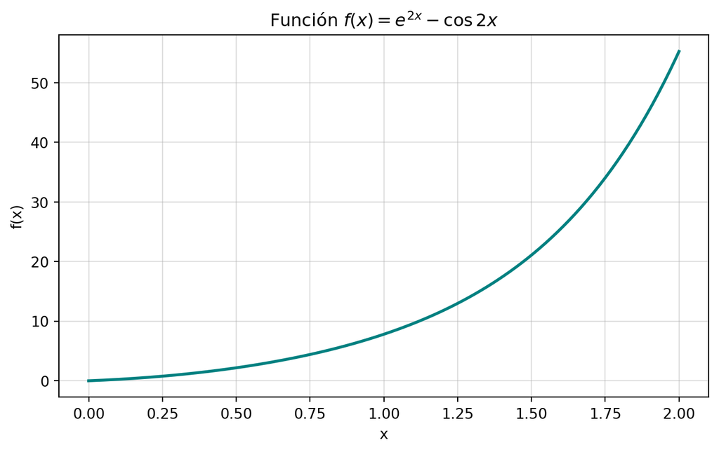

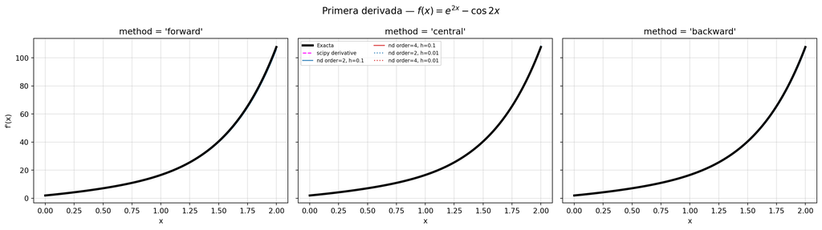

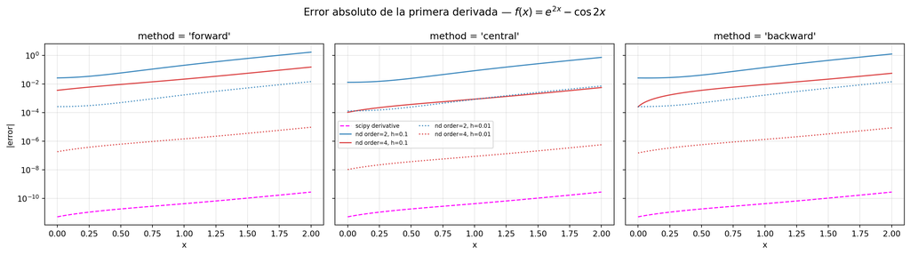

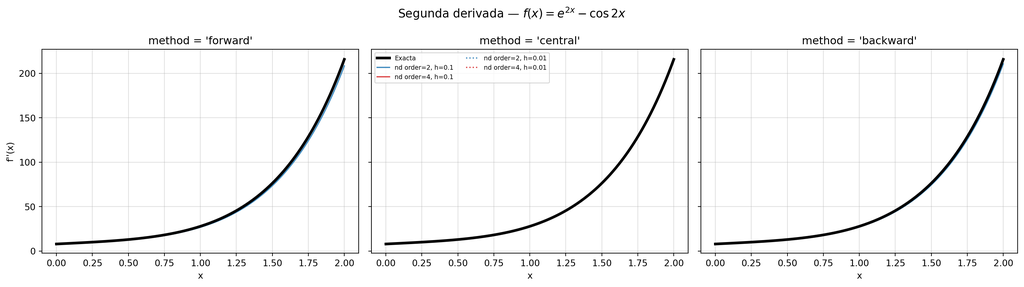

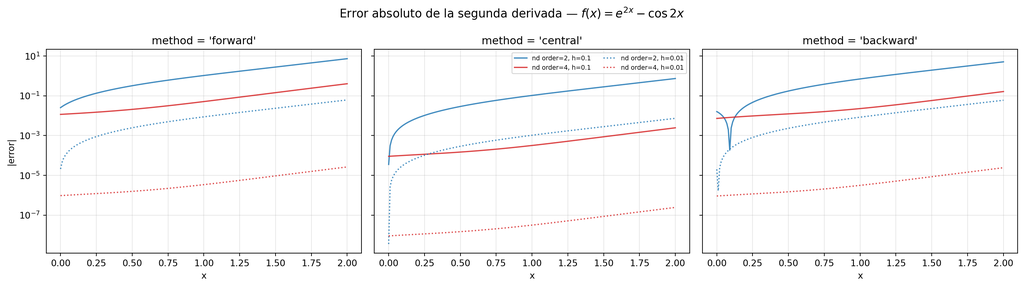

```python
f_a   = lambda x: np.exp(2*x) - np.cos(2*x)
fp_a  = lambda x: 2*np.exp(2*x) + 2*np.sin(2*x)
fpp_a = lambda x: 4*np.exp(2*x) + 4*np.cos(2*x)

analiza_derivadas(f_a, fp_a, fpp_a, 0, 2, r'$f(x)=e^{2x}-\cos 2x$')
```

## b) $f(x)=\log(x+2)-(x+1)^2$, $x\in [0,5]$

Derivadas exactas (con $\log=\ln$):
$$f'(x)=\frac{1}{x+2}-2(x+1), \qquad f''(x)=-\frac{1}{(x+2)^2}-2.$$

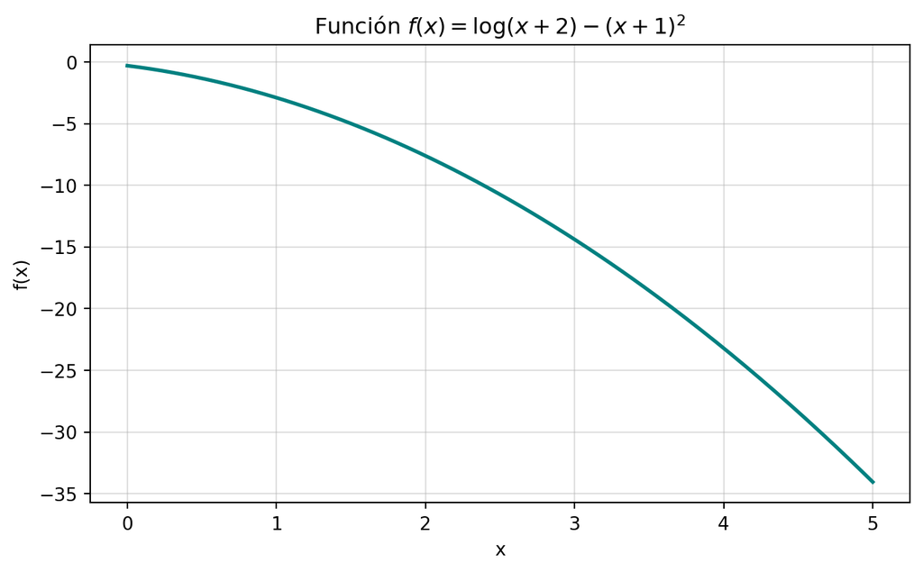

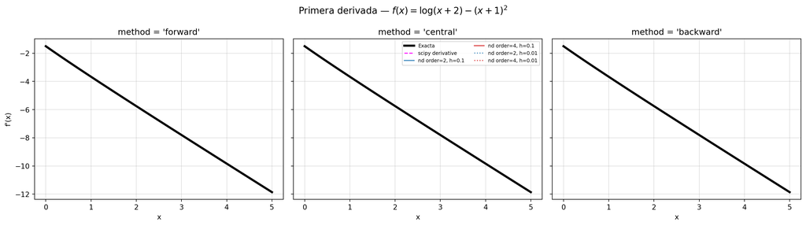

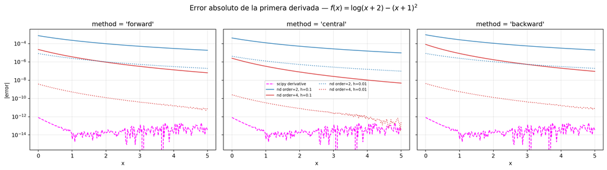

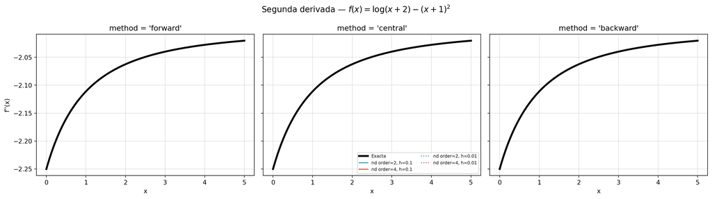

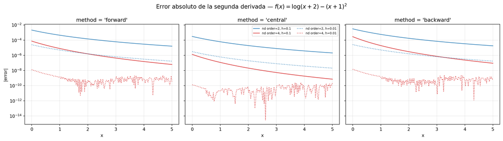

```python
f_b   = lambda x: np.log(x+2) - (x+1)**2
fp_b  = lambda x: 1/(x+2) - 2*(x+1)
fpp_b = lambda x: -1/(x+2)**2 - 2

analiza_derivadas(f_b, fp_b, fpp_b, 0, 5, r'$f(x)=\log(x+2)-(x+1)^2$')
```

## c) $f(x)=\sqrt{x}\,\operatorname{sen}(x^2)$, $x\in [0,\pi]$

Derivadas exactas:
$$f'(x)=\frac{\operatorname{sen}(x^2)}{2\sqrt{x}}+2x^{3/2}\cos(x^2),$$
$$f''(x)=-\tfrac{1}{4}x^{-3/2}\operatorname{sen}(x^2)+4\sqrt{x}\,\cos(x^2)-4x^{5/2}\operatorname{sen}(x^2).$$

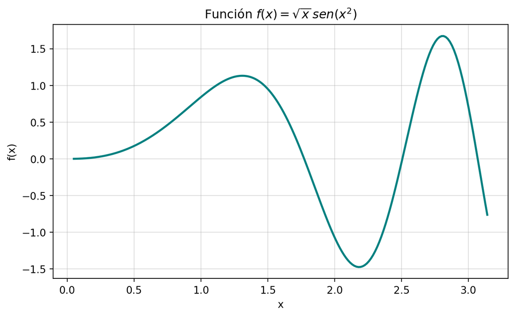

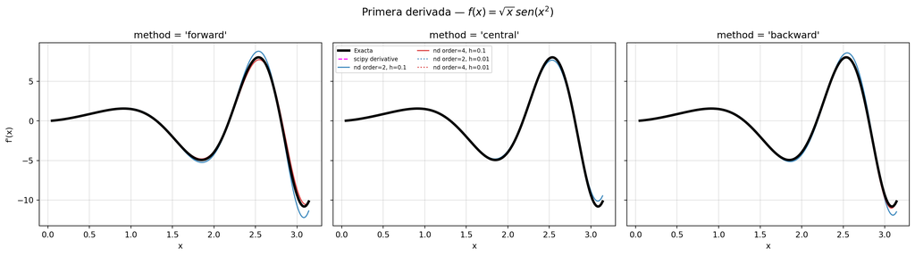

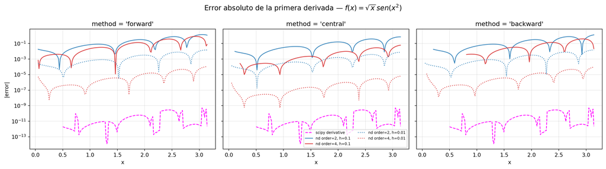

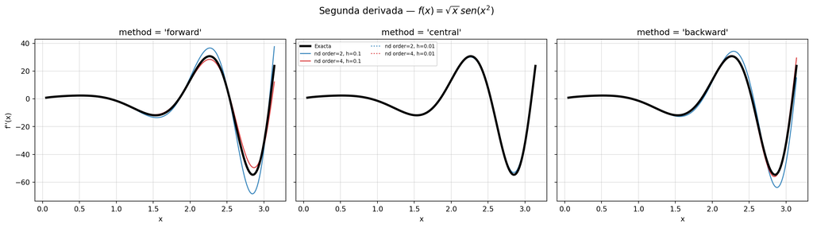

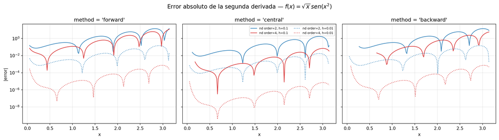

```python
f_c   = lambda x: np.sqrt(x) * np.sin(x**2)
fp_c  = lambda x: np.sin(x**2)/(2*np.sqrt(x)) + 2*x**1.5*np.cos(x**2)
fpp_c = lambda x: (-0.25*x**(-1.5)*np.sin(x**2)
                   + 4*np.sqrt(x)*np.cos(x**2)
                   - 4*x**2.5*np.sin(x**2))

analiza_derivadas(f_c, fp_c, fpp_c, 0, np.pi,
                  r'$f(x)=\sqrt{x}\,sen(x^2)$', eps=0.05)
```

## d) $f(x)=(\cos 3x)^2-e^{2x}$, $x\in [0,\pi/2]$

Derivadas exactas (usando $\cos^2 3x=\tfrac{1+\cos 6x}{2}$):
$$f'(x)=-3\operatorname{sen}(6x)-2e^{2x}, \qquad f''(x)=-18\cos(6x)-4e^{2x}.$$

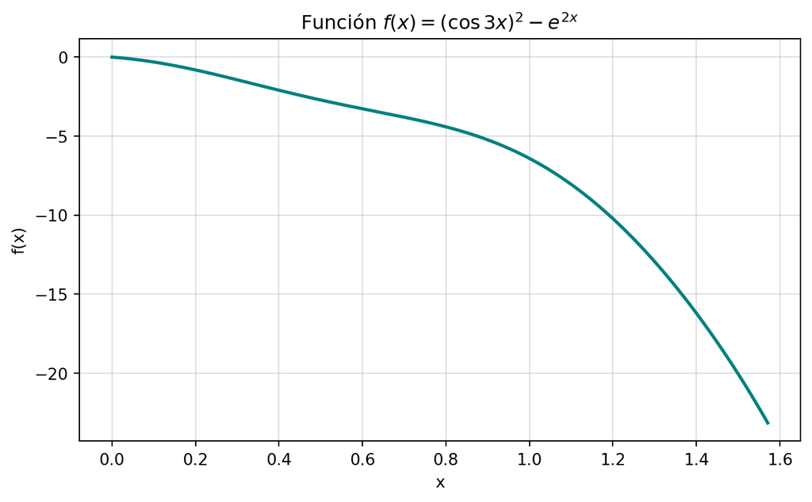

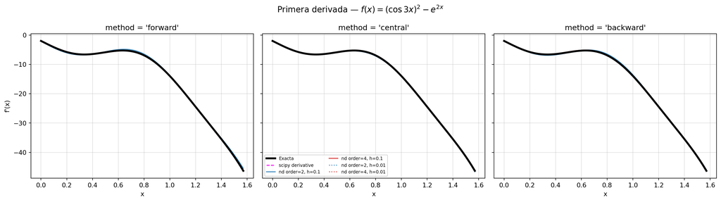

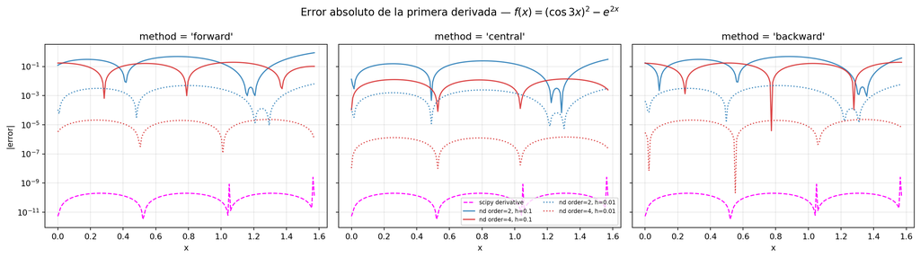

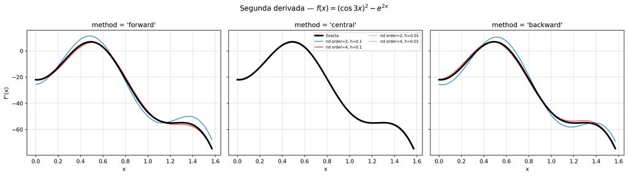

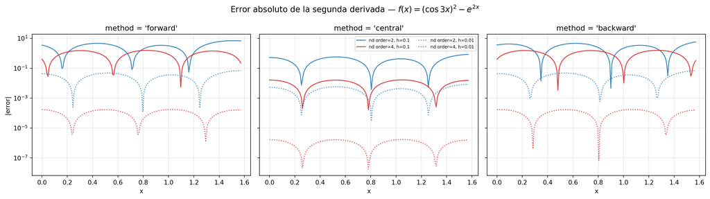

```python
f_d   = lambda x: np.cos(3*x)**2 - np.exp(2*x)
fp_d  = lambda x: -3*np.sin(6*x) - 2*np.exp(2*x)
fpp_d = lambda x: -18*np.cos(6*x) - 4*np.exp(2*x)

analiza_derivadas(f_d, fp_d, fpp_d, 0, np.pi/2,
                  r'$f(x)=(\cos 3x)^2-e^{2x}$')
```

**Observaciones del Ejercicio 1.** En todos los casos `scipy.differentiate.derivative` (que usa pasos adaptativos y un esquema de alto orden) prácticamente coincide con la derivada exacta. Para `nd.Derivative` el error disminuye al usar `order = 4` frente a `order = 2` y al reducir el paso $h$; el método `central` es el más preciso, mientras que `forward` y `backward` muestran mayor error, sobre todo cerca de los extremos del intervalo.

# Ejercicio 2

Elige 3 indicadores económicos del INEGI (del archivo `TIE_Inegi_long.xlsx`), realiza la gráfica de la serie temporal y de su derivada. Brinda un análisis de la gráfica y de la evolución del indicador a lo largo del tiempo.

```python
# Lectura del archivo INEGI con indicadores económicos mensuales (1993-2025).
# El archivo tiene una columna 'Fecha' y 42 columnas, cada una un indicador.
inegi = pd.read_excel("TIE_Inegi_long.xlsx")
inegi['Fecha'] = pd.to_datetime(inegi['Fecha'])
inegi = inegi.sort_values('Fecha').reset_index(drop=True)

print(f"Periodo: {inegi['Fecha'].min().date()} a {inegi['Fecha'].max().date()}")
print(f"Total de observaciones: {len(inegi)}")
print(f"\nIndicadores disponibles ({len(inegi.columns)-1}):")
for c in inegi.columns[1:]:
    print(f"  - {c}")
```

```
Periodo: 1993-01-01 a 2025-12-01
Total de observaciones: 396

Indicadores disponibles (42):
  - Actividad_economica
  - Actividades_primarias
  - Actividad_industrial
  - Volumen_fisico_construccion
  - Actividades_terciarias
  - Ingresos_bienes_pormenor
  - Inversion_fija_bruta
  - Precios_consumidor
  - Precios_productor
  - Precios_consumidor_subyacente
  - Tasa_desocupacion_urbana
  - Tendencia_empleo_manufacturas
  - Asegurados_IMSS
  - Expectativa_personal_ocupado
  - Importaciones_totales
  - Importaciones_no_petroleras
  - Exportaciones_totales
  - Exportaciones_petroleras
  - Exportaciones_no_petroleras
  - Precio_promedio_petroleo_crudo
  - TIIE
  - Cetes
  - Tasa_fondeo_gubernamental
  - Tipo_cambio_nominal
  - Tipo_cambio_real
  - IPC_BMV
  - Reservas_internacionales
  - Indicador_confianza_empresarial
  - Indicador agregado_tendencia
  - Indicador_pedidos_manufactureros
  - Indicador_confianza_consumidor
  - Expectativa_planta_equipo
  - Expectativa_inventarios_insumos
  - Indice_produccion_industrial_EUA
  - Produccion_manufacturera_EUA
  - Comercio_por_menor_EUA
  - Tasa_desempleo_EUA
  - Empleo_EUA
  - Tasa_bonos_tesoro_EUA
  - Standard_Poors_500
  - Dow_Jones
  - Confianza_consumidor_EUA
```

Elegimos **tres indicadores económicos** representativos de distintos aspectos de la economía mexicana:

1. **Tipo de cambio nominal** (peso/dólar): refleja la estabilidad cambiaria y las crisis.
2. **Tasa de desocupación urbana**: indicador del mercado laboral.
3. **Precios al consumidor (INPC)**: mide el nivel general de precios; su derivada es la inflación.

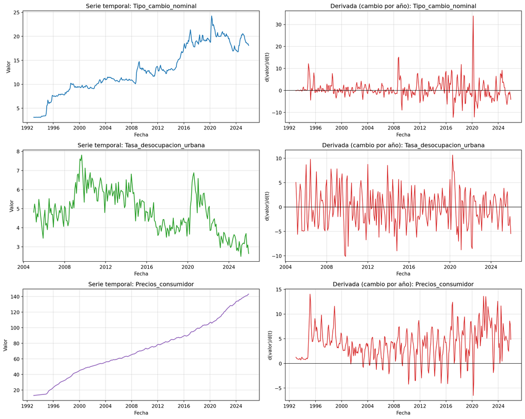

```python
indicadores = ['Tipo_cambio_nominal', 'Tasa_desocupacion_urbana', 'Precios_consumidor']
colores = ['tab:blue', 'tab:green', 'tab:purple']

fig, axes = plt.subplots(3, 2, figsize=(15, 12))
t = inegi['Fecha']
# Tiempo en años desde el inicio (para que la derivada tenga unidades por año)
t_num = (inegi['Fecha'] - inegi['Fecha'].min()).dt.days.values / 365.25

for i, (ind, col) in enumerate(zip(indicadores, colores)):
    y = inegi[ind].values.astype(float)

    # Se calcula la derivada solo donde hay datos (algunos indicadores tienen NaN)
    mask = ~np.isnan(y)
    dydt = np.full_like(y, np.nan)
    if mask.sum() > 2:
        dydt[mask] = np.gradient(y[mask], t_num[mask])

    # Serie temporal
    axes[i, 0].plot(t, y, color=col, lw=1.5)
    axes[i, 0].set_title(f'Serie temporal: {ind}')
    axes[i, 0].set_xlabel('Fecha'); axes[i, 0].set_ylabel('Valor')
    axes[i, 0].grid(True, alpha=0.4)

    # Derivada (tasa de cambio por año)
    axes[i, 1].plot(t, dydt, color='tab:red', lw=1.2)
    axes[i, 1].axhline(0, color='k', lw=0.8)
    axes[i, 1].set_title(f'Derivada (cambio por año): {ind}')
    axes[i, 1].set_xlabel('Fecha'); axes[i, 1].set_ylabel('d(valor)/d(t)')
    axes[i, 1].grid(True, alpha=0.4)

plt.tight_layout()
plt.show()
```

**Análisis de la evolución de los indicadores.**

**1. Tipo de cambio nominal (peso/dólar).** La serie muestra el deterioro estructural del peso mexicano frente al dólar, pasando de aproximadamente 3 pesos por dólar en 1993 a más de 20 pesos en años recientes. La derivada permite identificar con claridad los **episodios de depreciación abrupta**: el pico de 1994-1995 corresponde al *Error de Diciembre* (crisis del Tequila), donde el peso se devaluó violentamente; un segundo pico en 2008-2009 refleja la crisis financiera global; y un tercer pico en 2020 corresponde al choque de la pandemia de COVID-19. Los tramos donde la derivada es cercana a cero representan periodos de relativa estabilidad cambiaria.

**2. Tasa de desocupación urbana.** El desempleo en México oscila entre 2.5% y 8%, con picos claros en periodos de crisis. La derivada muestra **aumentos bruscos** en 2009 (crisis financiera mundial) y en 2020 (pandemia), seguidos de descensos graduales conforme la economía se recuperaba. Cuando la derivada cruza por cero después de un máximo, indica que el desempleo dejó de aumentar y comenzó a disminuir.

**3. Precios al consumidor (INPC).** La serie es **monótona creciente** porque los precios nominales casi nunca bajan; lo informativo es la **derivada**, que corresponde aproximadamente a la **inflación** (cambio del INPC por año). Se observa una inflación elevada en los años 90 (heredada de la crisis del Tequila), un descenso gradual gracias a la política de objetivos de inflación del Banco de México, y un nuevo repunte en 2021-2022 asociado a las disrupciones de oferta post-pandemia y al choque inflacionario global.

# Ejercicio 3

Calcular el valor exacto y las aproximaciones numéricas de la siguiente integral:

$$\begin{equation}
\int_0^4 x^2e^{-x} dx
\end{equation}$$

Como en el primer ejemplo del archivo `Ejemplos_10_Int_num.qmd`.

```python
# Valor EXACTO con sympy
xs = sp.symbols('x')
exacta_sym = sp.integrate(xs**2 * sp.exp(-xs), (xs, 0, 4))
valor_exacto = float(exacta_sym)
print("Valor exacto (simbólico):", sp.nsimplify(exacta_sym), "=", exacta_sym, "≈", valor_exacto)
```

```
Valor exacto (simbólico): 2 - 26*exp(-4) = 2 - 26*exp(-4) ≈ 1.5237933888929114
```

```python
g = lambda x: x**2 * np.exp(-x)
a, b = 0, 4

# 1) Cuadratura adaptativa (scipy quad)
val_quad, err_quad = integrate.quad(g, a, b)

# Malla para las reglas compuestas
n = 100
x = np.linspace(a, b, n+1)
y = g(x)

# 2) Regla del trapecio
val_trap = integrate.trapezoid(y, x)

# 3) Regla de Simpson
val_simp = integrate.simpson(y, x=x)

# 4) Sumas de Riemann (izquierda, derecha, punto medio)
dx = (b - a)/n
x_izq  = a + dx*np.arange(n)
x_der  = a + dx*np.arange(1, n+1)
x_med  = a + dx*(np.arange(n) + 0.5)
val_izq = np.sum(g(x_izq))*dx
val_der = np.sum(g(x_der))*dx
val_med = np.sum(g(x_med))*dx

tabla = pd.DataFrame({
    'Método': ['Exacto', 'quad (adaptativo)', 'Trapecio', 'Simpson',
               'Riemann izquierda', 'Riemann derecha', 'Punto medio'],
    'Valor': [valor_exacto, val_quad, val_trap, val_simp,
              val_izq, val_der, val_med]
})
tabla['Error absoluto'] = np.abs(tabla['Valor'] - valor_exacto)
tabla
```

|  | Método | Valor | Error absoluto |
| --- | --- | --- | --- |
| 0 | Exacto | 1.523793 | 0.000000e+00 |
| 1 | quad (adaptativo) | 1.523793 | 2.220446e-16 |
| 2 | Trapecio | 1.523774 | 1.955814e-05 |
| 3 | Simpson | 1.523793 | 8.579995e-08 |
| 4 | Riemann izquierda | 1.517913 | 5.880563e-03 |
| 5 | Riemann derecha | 1.529635 | 5.841446e-03 |
| 6 | Punto medio | 1.523803 | 9.787119e-06 |

El valor exacto es $\displaystyle\int_0^4 x^2e^{-x}\,dx = 2-26e^{-4}\approx 1.523793$. Las reglas de **Simpson** y **quad** reproducen el valor exacto con error prácticamente nulo, el **punto medio** y el **trapecio** dan muy buena aproximación, mientras que las sumas de Riemann por la izquierda y por la derecha son las menos precisas.

# Ejericicio 4

Aproximar las siguientes integrales con la función `integrate.quad` (de SciPy) y con el método de Montecarlo, en cada caso hacer una gráfica de la función e indicar el área bajo la curva.

```python
def montecarlo(f, a, b, N=200_000, seed=0):
    """Estimación Montecarlo de la integral de f en [a,b]."""
    rng = np.random.default_rng(seed)
    xs = rng.uniform(a, b, N)
    fx = f(xs)
    fx = fx[np.isfinite(fx)]           # se descartan posibles NaN/inf
    return (b - a) * np.mean(fx)

def grafica_area(f, a, b, titulo, a_plot=None, b_plot=None):
    """Grafica f y sombrea el área bajo la curva en [a,b]."""
    a_plot = a if a_plot is None else a_plot
    b_plot = b if b_plot is None else b_plot
    x = np.linspace(a_plot, b_plot, 400)
    plt.figure(figsize=(7.5, 4))
    plt.plot(x, f(x), color='navy', lw=2)
    mask = (x >= a) & (x <= b)
    plt.fill_between(x[mask], f(x[mask]), alpha=0.4, color='skyblue',
                     label='Área bajo la curva')
    plt.axhline(0, color='k', lw=0.8)
    plt.title(titulo); plt.xlabel('x'); plt.ylabel('f(x)')
    plt.grid(True, alpha=0.4); plt.legend()
    plt.show()

def resolver(f, a, b, titulo, exacto=None, a_plot=None, b_plot=None,
             a_mc=None, b_mc=None):
    """quad + Montecarlo + gráfica, devuelve un resumen."""
    val_quad, _ = integrate.quad(f, a, b)
    a_mc = a if a_mc is None else a_mc
    b_mc = b if b_mc is None else b_mc
    val_mc = montecarlo(f, a_mc, b_mc)
    grafica_area(f, a_mc, b_mc, titulo, a_plot, b_plot)
    fila = {'Integral': titulo, 'quad': val_quad, 'Montecarlo': val_mc}
    if exacto is not None:
        fila['Exacto'] = exacto
        fila['|quad-exacto|'] = abs(val_quad - exacto)
    print(f"quad = {val_quad:.8f}   |   Montecarlo = {val_mc:.8f}", end='')
    if exacto is not None:
        print(f"   |   exacto = {exacto:.8f}")
    else:
        print()
    return fila
```

## a) $\int_0^1 e^{-x^2}\,dx$

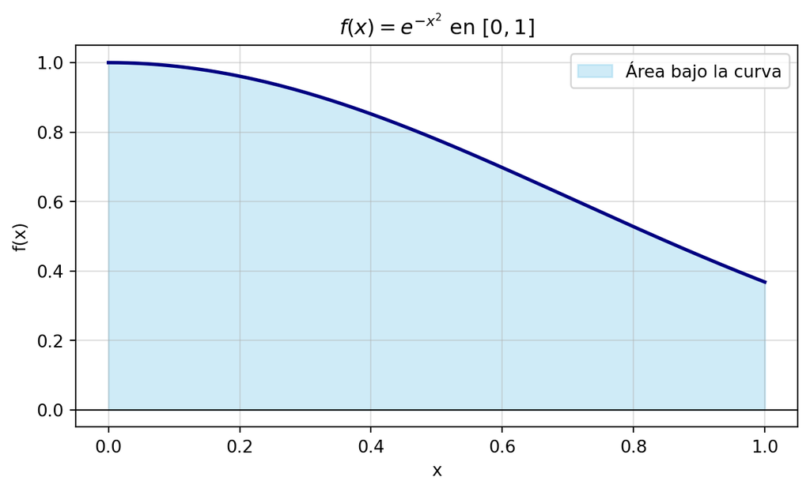

```
quad = 0.74682413   |   Montecarlo = 0.74738396   |   exacto = 0.74682413
```

```python
fa = lambda x: np.exp(-x**2)
exacto_a = np.sqrt(np.pi)/2 * special.erf(1)
resolver(fa, 0, 1, r'$f(x)=e^{-x^2}$ en $[0,1]$', exacto=exacto_a);
```

## b) $\int_0^\pi \operatorname{sen}(x^2)\,dx$

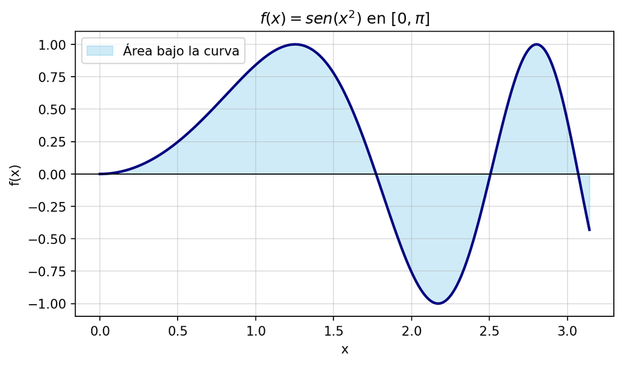

```
quad = 0.77265171   |   Montecarlo = 0.77140975
```

```python
fb = lambda x: np.sin(x**2)
resolver(fb, 0, np.pi, r'$f(x)=sen(x^2)$ en $[0,\pi]$');
```

## c) $\int_\pi^{3\pi} \frac{\operatorname{sen}(x)}{x}\,dx$

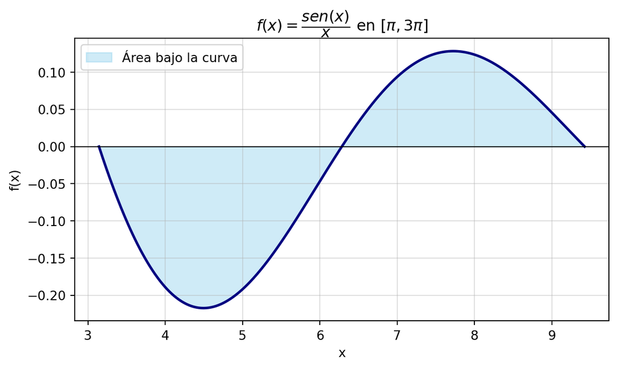

```
quad = -0.17717525   |   Montecarlo = -0.17749898   |   exacto = -0.17717525
```

```python
fc = lambda x: np.sin(x)/x
# Exacto vía la integral seno: Si(3π) - Si(π)
si_3pi, _ = special.sici(3*np.pi)
si_pi,  _ = special.sici(np.pi)
exacto_c = si_3pi - si_pi
resolver(fc, np.pi, 3*np.pi, r'$f(x)=\dfrac{sen(x)}{x}$ en $[\pi,3\pi]$', exacto=exacto_c);
```

## d) $\int_0^\infty e^{-x^2}\cos(x)\,dx$

Integral impropia. `quad` admite directamente el límite infinito; para Montecarlo se **trunca** el dominio en un valor grande donde el integrando es despreciable.

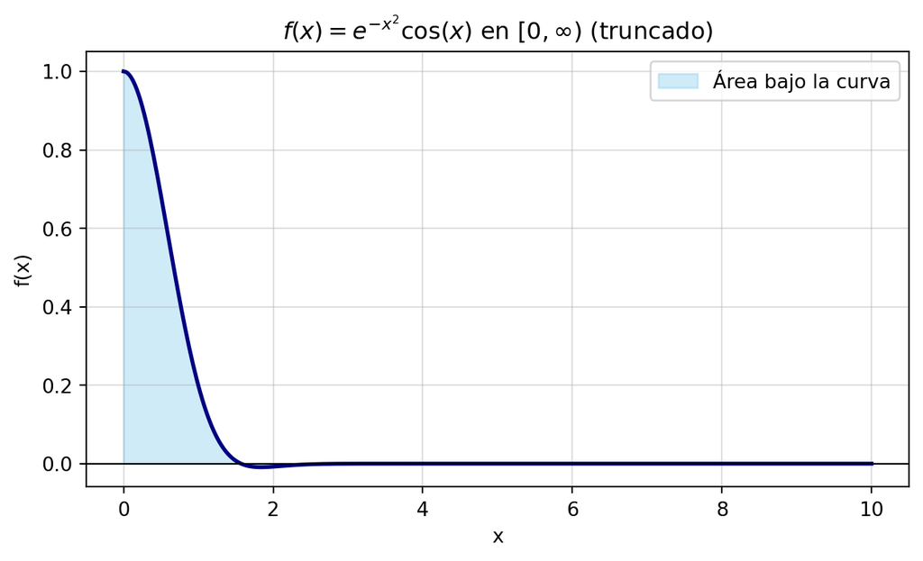

```
quad = 0.69019422  |  Montecarlo (trunc. en 10) = 0.69121833  |  exacto = 0.69019422
```

```python
fd = lambda x: np.exp(-x**2)*np.cos(x)
exacto_d = np.sqrt(np.pi)/2 * np.exp(-1/4)
# quad con límite infinito
vq, _ = integrate.quad(fd, 0, np.inf)
vmc = montecarlo(fd, 0, 10)          # truncado en x=10
grafica_area(fd, 0, 10, r'$f(x)=e^{-x^2}\cos(x)$ en $[0,\infty)$ (truncado)')
print(f"quad = {vq:.8f}  |  Montecarlo (trunc. en 10) = {vmc:.8f}  |  exacto = {exacto_d:.8f}")
```

## e) $\int_0^1 x^x\,dx$

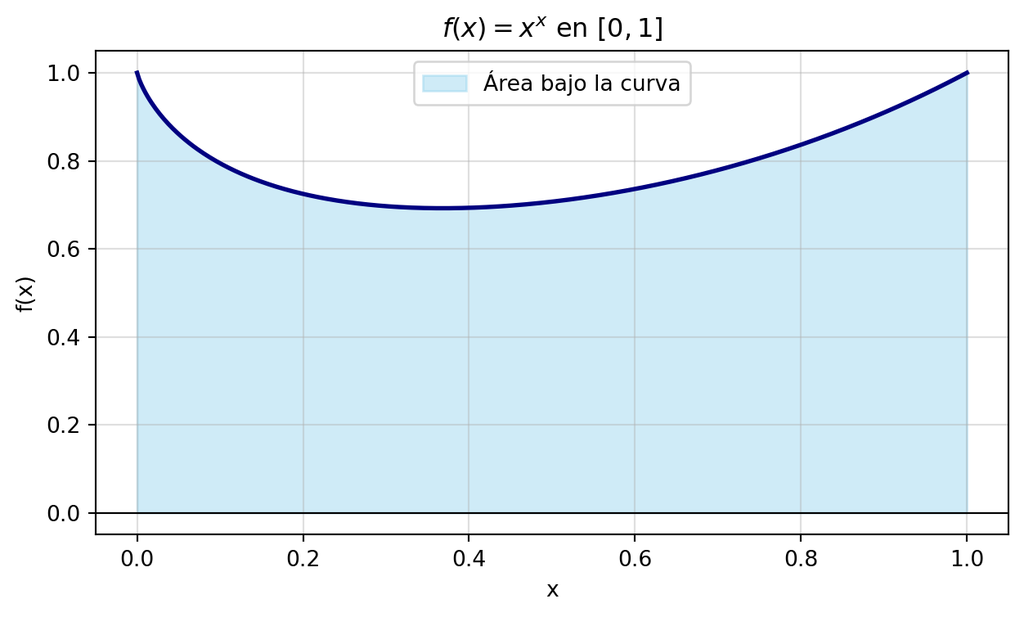

```
quad = 0.78343051   |   Montecarlo = 0.78311957   |   exacto = 0.78343051
```

```python
fe = lambda x: np.power(x, x)
# "Sophomore's dream":  ∫_0^1 x^x dx = Σ (-1)^(n+1) n^(-n)
exacto_e = sum((-1)**(n+1) * n**(-n) for n in range(1, 30))
resolver(fe, 0, 1, r'$f(x)=x^x$ en $[0,1]$', exacto=exacto_e);
```

## f) $\int_1^5 e^{-x^2}x^3\,dx$

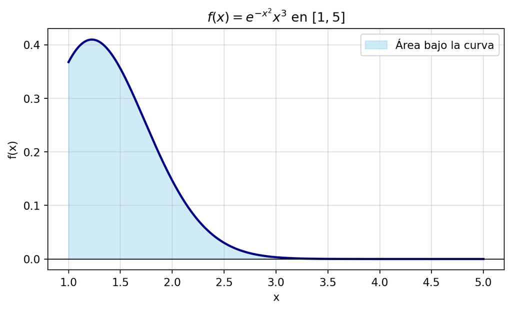

```
quad = 0.36787944   |   Montecarlo = 0.36838546
```

```python
ff = lambda x: np.exp(-x**2)*x**3
resolver(ff, 1, 5, r'$f(x)=e^{-x^2}x^3$ en $[1,5]$');
```

## g) $\int_0^\infty \frac{x}{e^x-1}\,dx$

Integral impropia cuyo valor exacto es $\dfrac{\pi^2}{6}$. En $x=0$ el integrando tiene límite $1$; se define con cuidado para evitar la indeterminación $0/0$.

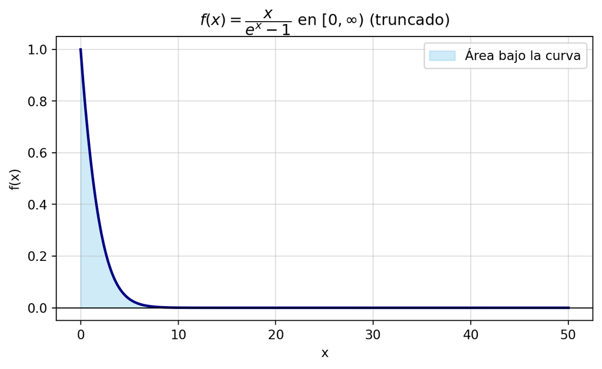

```
quad = 1.64493407  |  Montecarlo (trunc. en 50) = 1.63777496  |  exacto = 1.64493407
```

```python
def fg(x):
    x = np.asarray(x, dtype=float)
    out = np.where(x > 1e-12, x/np.expm1(x), 1.0)  # expm1(x)=e^x-1 estable
    return out

exacto_g = np.pi**2/6
vq, _ = integrate.quad(fg, 0, np.inf)
vmc = montecarlo(fg, 1e-12, 50)       # truncado en x=50
grafica_area(fg, 1e-3, 50, r'$f(x)=\dfrac{x}{e^x-1}$ en $[0,\infty)$ (truncado)')
print(f"quad = {vq:.8f}  |  Montecarlo (trunc. en 50) = {vmc:.8f}  |  exacto = {exacto_g:.8f}")
```

## h) $\int_0^1 \frac{1}{\sqrt{x^4+1}}\,dx$

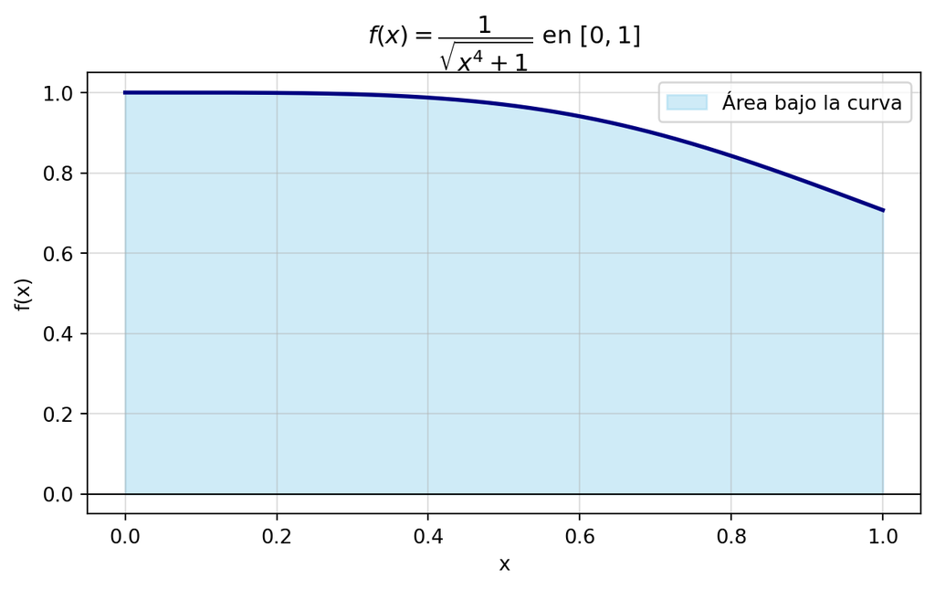

```
quad = 0.92703734   |   Montecarlo = 0.92735736
```

```python
fh = lambda x: 1/np.sqrt(x**4 + 1)
resolver(fh, 0, 1, r'$f(x)=\dfrac{1}{\sqrt{x^4+1}}$ en $[0,1]$');
```

**Observaciones del Ejercicio 4.** La cuadratura adaptativa `quad` coincide con los valores exactos (cuando existe forma cerrada) hasta varios decimales. El método de Montecarlo es mucho menos preciso: su error decrece como $1/\sqrt{N}$, por lo que con $N=2\times 10^5$ muestras se obtienen 2–3 cifras significativas. En las integrales impropias (d y g) se trunca el dominio para Montecarlo en un punto donde el integrando ya es despreciable.

# Ejercicio 5

Aproximar las siguientes integrales dobles y triples, llevar a cabo la gráfica cuando se indique y comparar con el valor *exacto* de la integral.

## a) $\int_{-1}^{1}\int_1^2 (3y^2-x^2+5)\, dx\, dy$ (con gráfica)

```
dblquad = 7.33333333   |   exacto = 7.33333333  (22/3)
```

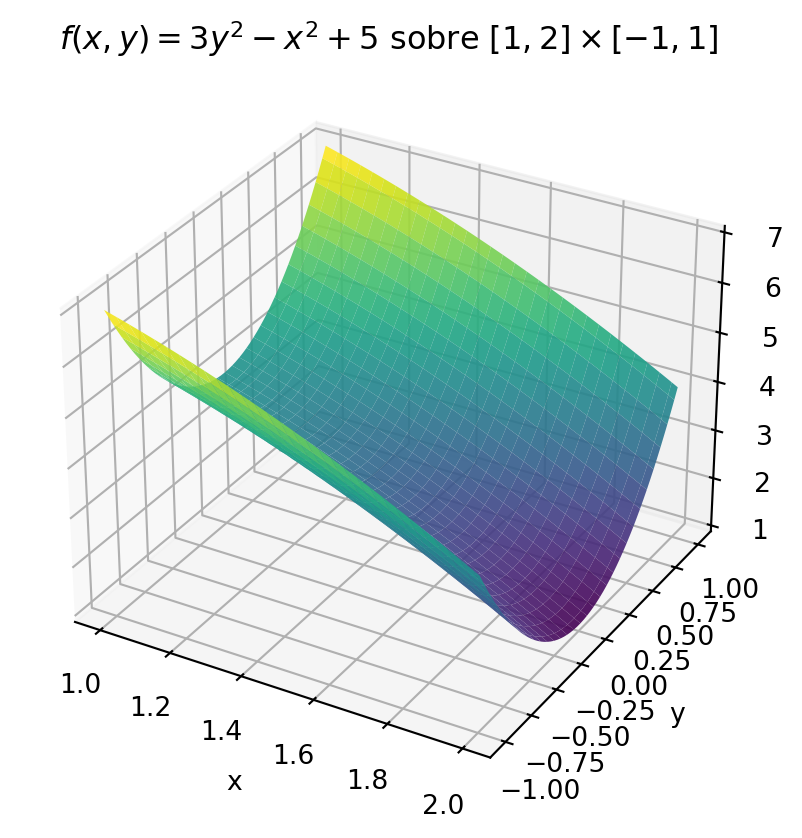

```python
# integrate.dblquad(func, a, b, gfun, hfun) integra func(y, x) con x en [a,b], y en [g(x),h(x)]
F_a = lambda y, x: 3*y**2 - x**2 + 5
# Variable externa: y en [-1,1]; interna: x en [1,2]
val_a, _ = integrate.dblquad(lambda x, y: F_a(y, x), -1, 1, 1, 2)

# Valor exacto con sympy
xx, yy = sp.symbols('x y')
exacto_a5 = sp.integrate(sp.integrate(3*yy**2 - xx**2 + 5, (xx, 1, 2)), (yy, -1, 1))
print(f"dblquad = {val_a:.8f}   |   exacto = {float(exacto_a5):.8f}  ({exacto_a5})")

# Gráfica de la superficie sobre la región [1,2] x [-1,1]
xg = np.linspace(1, 2, 60)
yg = np.linspace(-1, 1, 60)
X, Y = np.meshgrid(xg, yg)
Z = 3*Y**2 - X**2 + 5
fig = plt.figure(figsize=(8, 5))
ax = fig.add_subplot(111, projection='3d')
ax.plot_surface(X, Y, Z, cmap='viridis', alpha=0.9)
ax.set_xlabel('x'); ax.set_ylabel('y'); ax.set_zlabel('f(x,y)')
ax.set_title(r'$f(x,y)=3y^2-x^2+5$ sobre $[1,2]\times[-1,1]$')
plt.show()
```

## b) $\int_{0}^{6}\int_1^5 \sqrt{x+4y}\, dx\, dy$

```python
F_b = lambda x, y: np.sqrt(x + 4*y)
# y externa en [0,6]; x interna en [1,5]
val_b, _ = integrate.dblquad(F_b, 0, 6, 1, 5)
exacto_b5 = sp.integrate(sp.integrate(sp.sqrt(xx + 4*yy), (xx, 1, 5)), (yy, 0, 6))
print(f"dblquad = {val_b:.8f}   |   exacto = {float(exacto_b5):.8f}")
```

```
dblquad = 89.93479356   |   exacto = 89.93479356
```

## c) $\int_{1}^{e}\int_0^{\log(x)} x^3 \, dy\, dx$

La variable interna ($y$) va de $0$ a $\log(x)$ y la externa ($x$) de $1$ a $e$.

```python
# x externa en [1,e]; y interna en [0, log(x)]
F_c = lambda y, x: x**3
val_c, _ = integrate.dblquad(F_c, 1, np.e, lambda x: 0, lambda x: np.log(x))
exacto_c5 = sp.integrate(sp.integrate(xx**3, (yy, 0, sp.log(xx))), (xx, 1, sp.E))
print(f"dblquad = {val_c:.8f}   |   exacto = {float(exacto_c5):.8f}  ({sp.nsimplify(exacto_c5)})")
```

```
dblquad = 10.29965313   |   exacto = 10.29965313  (1/16 + 3*exp(4)/16)
```

## d) $\iint_D 30y e^x\, dx\, dy$, con $D$ la región mostrada

La región $D$ está acotada por las rectas $y=\dfrac{x}{4}$ y $y=x$ para $x\in[0,4]$ (rectas que pasan por el origen hacia $(4,1)$ y $(4,4)$).

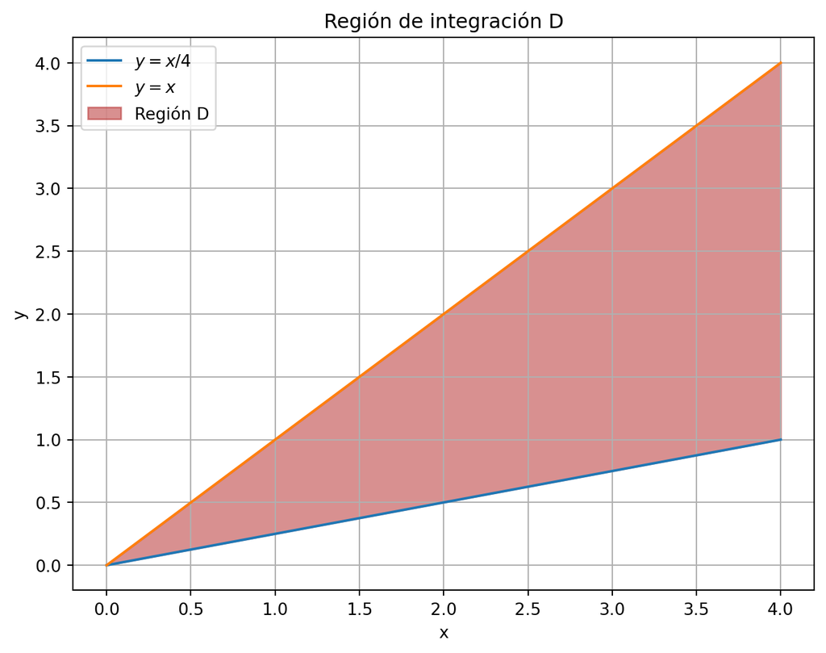

```python
x_val = np.array([0, 4])
y_val1 = np.array([0, 1])
y_val2 = np.array([0, 4])

plt.figure(figsize=(8, 6))
plt.plot(x_val, y_val1, label=r'$y=x/4$')
plt.plot(x_val, y_val2, label=r'$y=x$')
plt.fill_between(x_val, y1=y_val1, y2=y_val2, color="firebrick", alpha=0.5,
                 label='Región D')
plt.legend(); plt.xlabel('x'); plt.ylabel('y')
plt.title('Región de integración D')
plt.grid()
plt.show()
```

```python
# x externa en [0,4]; y interna en [x/4, x]
F_d = lambda y, x: 30*y*np.exp(x)
val_d, _ = integrate.dblquad(F_d, 0, 4, lambda x: x/4, lambda x: x)
exacto_d5 = sp.integrate(sp.integrate(30*yy*sp.exp(xx), (yy, xx/4, xx)), (xx, 0, 4))
print(f"dblquad = {val_d:.8f}   |   exacto = {float(exacto_d5):.8f}")
```

```
dblquad = 7649.73984841   |   exacto = 7649.73984841
```

## e) $\iiint_B z e^{x+y}\, dx\, dy\, dz$, $B=[0,1]^3$

```python
# tplquad(func, a, b, gfun, hfun, qfun, rfun): func(z, y, x), x en [a,b],
# y en [g(x),h(x)], z en [q(x,y), r(x,y)]
F_e = lambda z, y, x: z*np.exp(x + y)
val_e, _ = integrate.tplquad(F_e, 0, 1, 0, 1, 0, 1)
zz = sp.symbols('z')
exacto_e5 = sp.integrate(sp.integrate(sp.integrate(zz*sp.exp(xx+yy),
            (zz, 0, 1)), (yy, 0, 1)), (xx, 0, 1))
print(f"tplquad = {val_e:.8f}   |   exacto = {float(exacto_e5):.8f}  ({sp.nsimplify(exacto_e5)})")
```

```
tplquad = 1.47624622   |   exacto = 1.47624622  (-E/2 + 1/2 + E*(-1 + E)/2)
```

## f) $\int_0^1 \int_0^x \int_0^y (y+xz)\, dz\, dy\, dx$

```python
# x en [0,1]; y en [0,x]; z en [0,y]
F_f = lambda z, y, x: y + x*z
val_f, _ = integrate.tplquad(F_f, 0, 1, lambda x: 0, lambda x: x,
                             lambda x, y: 0, lambda x, y: y)
exacto_f5 = sp.integrate(sp.integrate(sp.integrate(yy + xx*zz,
            (zz, 0, yy)), (yy, 0, xx)), (xx, 0, 1))
print(f"tplquad = {val_f:.8f}   |   exacto = {float(exacto_f5):.8f}  ({sp.nsimplify(exacto_f5)})")
```

```
tplquad = 0.11666667   |   exacto = 0.11666667  (7/60)
```

**Observaciones del Ejercicio 5.** En todos los casos las rutinas `dblquad` y `tplquad` de SciPy reproducen el valor exacto (calculado simbólicamente con `sympy`) hasta la precisión de la máquina, confirmando la validez de las aproximaciones numéricas.

# Ejercicio 6

De `scipy.stats` elige 5 distribuciones continuas diferentes de probabilidad continua, realiza la gráfica y encuentra la probabilidad que la variable aleatoria tome un valor en un intervalo dado. Compara el resultado con el método `cdf`.

Elegimos las distribuciones **Normal**, **Exponencial**, **Gamma**, **Beta** y **Log-normal**. Para cada una se grafica la densidad (pdf), se sombrea el intervalo de interés $[a,b]$ y se calcula $P(a\le X\le b)$ de dos formas: integrando la densidad con `integrate.quad` y mediante la diferencia de la función de distribución acumulada, $F(b)-F(a)$ (método `cdf`).

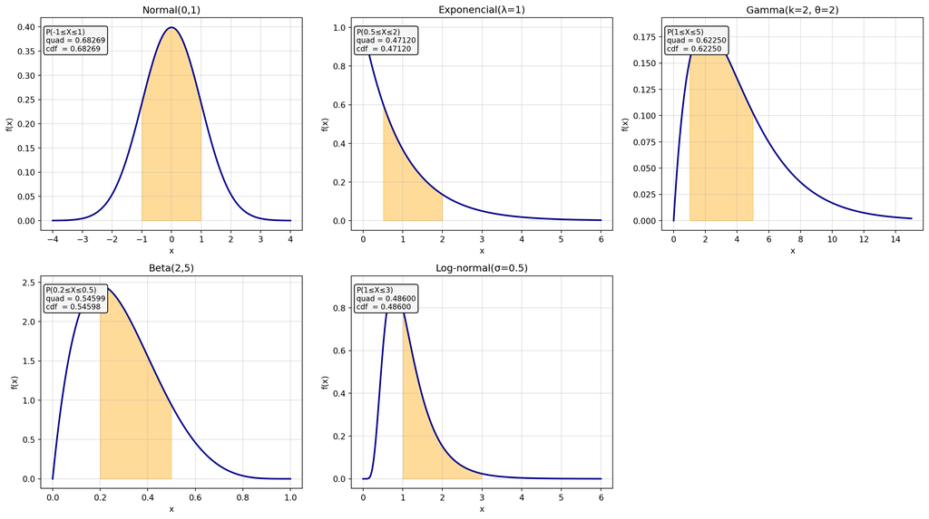

|  | Distribución | Intervalo | P (quad) | P (cdf) | Diferencia |
| --- | --- | --- | --- | --- | --- |
| 0 | Normal(0,1) | [-1, 1] | 0.682689 | 0.682689 | 1.110223e-16 |
| 1 | Exponencial(λ=1) | [0.5, 2] | 0.471195 | 0.471195 | 0.000000e+00 |
| 2 | Gamma(k=2, θ=2) | [1, 5] | 0.622498 | 0.622498 | 0.000000e+00 |
| 3 | Beta(2,5) | [0.2, 0.5] | 0.545985 | 0.545985 | 3.330669e-16 |
| 4 | Log-normal(σ=0.5) | [1, 3] | 0.485998 | 0.485998 | 1.110223e-16 |

```python
# (nombre, objeto de distribución congelado, intervalo [a,b], rango de graficación)
distribuciones = [
    ("Normal(0,1)",       stats.norm(loc=0, scale=1),        (-1, 1),   (-4, 4)),
    ("Exponencial(λ=1)",  stats.expon(scale=1),              (0.5, 2),  (0, 6)),
    ("Gamma(k=2, θ=2)",   stats.gamma(a=2, scale=2),         (1, 5),    (0, 15)),
    ("Beta(2,5)",         stats.beta(a=2, b=5),              (0.2, 0.5),(0, 1)),
    ("Log-normal(σ=0.5)", stats.lognorm(s=0.5),              (1, 3),    (0, 6)),
]

filas = []
fig, axes = plt.subplots(2, 3, figsize=(16, 9))
axes = axes.ravel()

for ax, (nombre, dist, (a, b), (xlo, xhi)) in zip(axes, distribuciones):
    x = np.linspace(xlo, xhi, 400)
    ax.plot(x, dist.pdf(x), color='darkblue', lw=2)
    mask = (x >= a) & (x <= b)
    ax.fill_between(x[mask], dist.pdf(x[mask]), alpha=0.4, color='orange')
    ax.set_title(nombre); ax.set_xlabel('x'); ax.set_ylabel('f(x)')
    ax.grid(True, alpha=0.4)

    # P(a<=X<=b) por integración de la densidad
    p_quad, _ = integrate.quad(dist.pdf, a, b)
    # P(a<=X<=b) con la cdf
    p_cdf = dist.cdf(b) - dist.cdf(a)

    ax.text(0.02, 0.95, f"P({a}≤X≤{b})\nquad = {p_quad:.5f}\ncdf  = {p_cdf:.5f}",
            transform=ax.transAxes, va='top', fontsize=9,
            bbox=dict(boxstyle='round', fc='whitesmoke'))

    filas.append({'Distribución': nombre, 'Intervalo': f'[{a}, {b}]',
                  'P (quad)': p_quad, 'P (cdf)': p_cdf,
                  'Diferencia': abs(p_quad - p_cdf)})

# Se oculta el sexto eje vacío
axes[-1].axis('off')
plt.tight_layout()
plt.show()

pd.DataFrame(filas)
```

**Observaciones del Ejercicio 6.** Para las cinco distribuciones continuas la probabilidad calculada integrando numéricamente la densidad con `quad` coincide (hasta la precisión numérica) con la obtenida mediante la función de distribución acumulada `cdf`, ya que por definición $P(a\le X\le b)=\int_a^b f(x)\,dx = F(b)-F(a)$. La columna *Diferencia* confirma que el error entre ambos métodos es prácticamente cero.